# Introduction

This project aims to analyze a medical data set gathered at the Security Forces Hospital during 2019. This medical data has been gathered to investigate how the Body Mass Index (BMI) is interpeted and understood among patients. First, a breif assessing of the data set will be conducted. The point from assessing the data is to detect issues and clean them later. The last part is the analysis part where several questions are proposed and answered. Finally, a summary conclusion about all the previous stages is made.

# Assessing

> Now, after we had reshaped the data and organize it properly, we will start assessing and exploring the variabled to dtect patterns and understand the nature of this data set.

```python
df.describe() # summary statistics
```

|  | hight | weight | age | q12 | q13 | q14 | diabetes | HTN | cholesterol | heart | siblings_obesity | know_BMI | doctor_discussion | BMI |
| --- | --- | --- | --- | --- | --- | --- | --- | --- | --- | --- | --- | --- | --- | --- |
| count | 426.000000 | 426.000000 | 426.000000 | 128.000000 | 128.000000 | 128.00000 | 426.000000 | 426.000000 | 426.000000 | 426.000000 | 426.000000 | 426.000000 | 426.000000 | 426.000000 |
| mean | 165.845070 | 87.789671 | 39.563380 | 4.000000 | 3.937500 | 5.18750 | 0.284038 | 0.131455 | 0.037559 | 0.565728 | 0.302817 | 0.169014 | 0.056338 | 32.518823 |
| std | 12.660989 | 21.928957 | 12.300052 | 1.587352 | 1.566128 | 0.95365 | 0.451485 | 0.338295 | 0.190350 | 0.496244 | 0.460017 | 0.375205 | 0.230844 | 10.653707 |
| min | 112.000000 | 47.000000 | 2.000000 | 1.000000 | 1.000000 | 2.00000 | 0.000000 | 0.000000 | 0.000000 | 0.000000 | 0.000000 | 0.000000 | 0.000000 | 16.000000 |
| 25% | 162.000000 | 74.000000 | 29.000000 | 3.000000 | 3.750000 | 5.00000 | 0.000000 | 0.000000 | 0.000000 | 0.000000 | 0.000000 | 0.000000 | 0.000000 | 26.365603 |
| 50% | 169.000000 | 86.000000 | 38.000000 | 3.500000 | 4.000000 | 5.00000 | 0.000000 | 0.000000 | 0.000000 | 1.000000 | 0.000000 | 0.000000 | 0.000000 | 29.903029 |
| 75% | 173.000000 | 101.000000 | 48.000000 | 6.000000 | 4.500000 | 6.00000 | 1.000000 | 0.000000 | 0.000000 | 1.000000 | 1.000000 | 0.000000 | 0.000000 | 35.222856 |
| max | 186.000000 | 149.000000 | 65.000000 | 6.000000 | 6.000000 | 6.00000 | 1.000000 | 1.000000 | 1.000000 | 1.000000 | 1.000000 | 1.000000 | 1.000000 | 71.176619 |

# Univariate Exploration

> Examine the distribution of age.

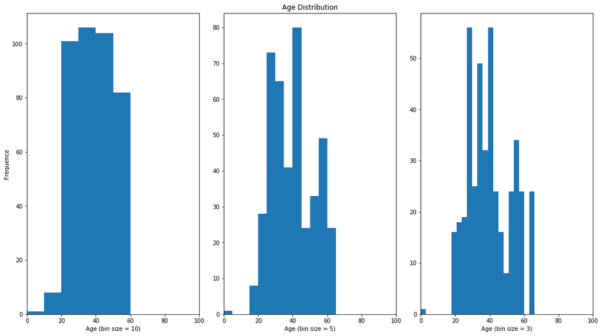

```python
#  creat three histograms with different bin sizes

plt.figure(figsize = [14.7,8.27]);


# first histogram
plt.subplot(1,3,1)
plt.tight_layout()
bin_size = np.arange(0, df['age'].max()+2, 10)
plt.hist(data=df, x='age', bins= bin_size);
plt.xlim([0,100]);
plt.xlabel('Age (bin size = 10)');
plt.ylabel('Frequence');

# second histogram
plt.subplot(1,3,2)
plt.title('Age Distribution');
plt.tight_layout()
bin_size = np.arange(0, df['age'].max()+2, 5)
plt.hist(data=df, x='age', bins = bin_size);
plt.xlim([0,100]);
plt.xlabel('Age (bin size = 5)');

#third histogram
plt.subplot(1,3,3)
plt.tight_layout()
bin_size = np.arange(0, df['age'].max()+2, 3)
plt.hist(data=df, x='age', bins=bin_size);
plt.xlim([0,100]);
plt.xlabel('Age (bin size = 3)');
```

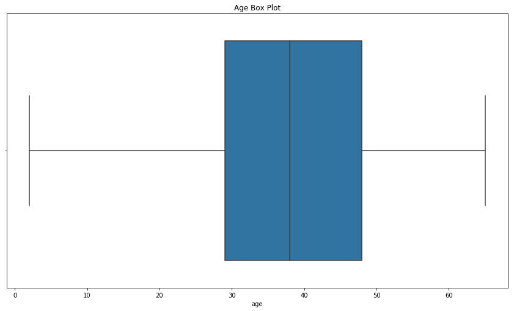

```python
# have a box plot for age

plt.figure(figsize = [14.7, 8.27])
base_color = sb.color_palette()[0]
sb.boxplot(data=df, x='age', color=base_color);
plt.title('Age Box Plot');
```

> It appers that the age distribution has no fixed shape with concetration in the interval [30,40]. Also, no outlires are seen in the box plot

> Let us look now at the distribution of the main variable of interest 'BMI'

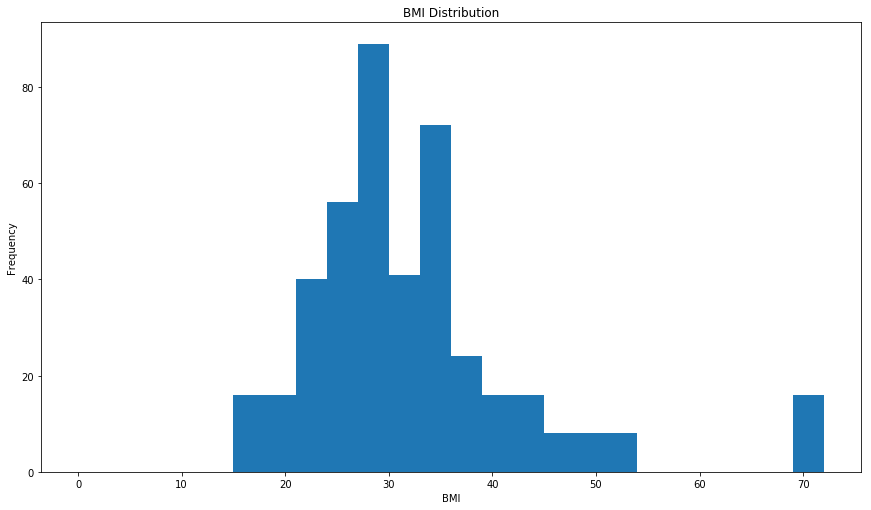

```python
# creat histogram with bin size =3

plt.figure(figsize=[14.7, 8.27])
bin_size = np.arange(0, df['BMI'].max()+2, 3)
plt.hist(data= df, x='BMI', bins = bin_size);
plt.xlabel('BMI');
plt.ylabel('Frequency');
plt.title('BMI Distribution');
```

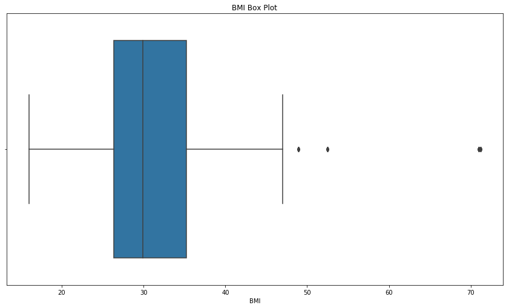

```python
# creat boxplot for BMI

plt.figure(figsize=[14.7,8.27])
color_base = sb.color_palette()[0]
sb.boxplot(data =df, x='BMI', color=base_color);
plt.title('BMI Box Plot');
```

> It appears that BMI variable is approximately normal with few outliers. The IQR (Inter Quartile Range) is very narrow and the maen BMI is very close to 30 (weighted).

> what is the proportion of each gender?

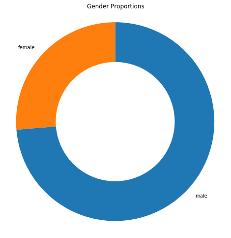

```python
# creat a donut chart

plt.figure(figsize=[14.7,8.27])
sorted_counts = df['gender'].value_counts()
plt.pie(sorted_counts, labels = sorted_counts.index, startangle=90, counterclock=False,
           wedgeprops = {'width':0.4});
plt.title('Gender Proportions');
plt.axis('square');
```

> Clearly, men constitute a proportion of 75%.

> Examin education level

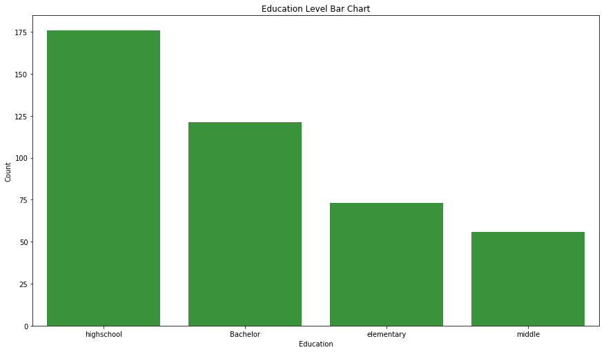

```python
# creat a bar chart for education level

plt.figure(figsize=[14.7,8.27])
base_color = sb.color_palette()[2]
sb.countplot(data=df, x='education', color=base_color);
plt.title('Education Level Bar Chart');
plt.xlabel('Education');
plt.ylabel('Count');
```

> Majority had education up to highschool with a large number having bachelor.

> Examine job status variable

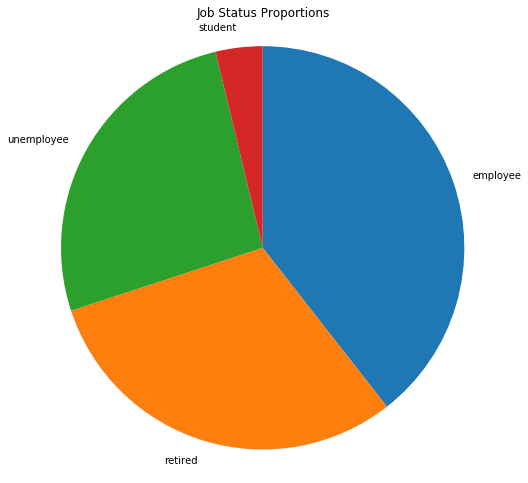

```python
# create a pie chart for job status

plt.figure(figsize=[14.7,8.27])
sorted_counts = df['job_status'].value_counts()
plt.pie(sorted_counts, labels = sorted_counts.index, startangle=90, counterclock = False);
plt.title('Job Status Proportions');
plt.axis('square');
```

# Multivariate Exploration

> Examine the correlations between all numeric variables

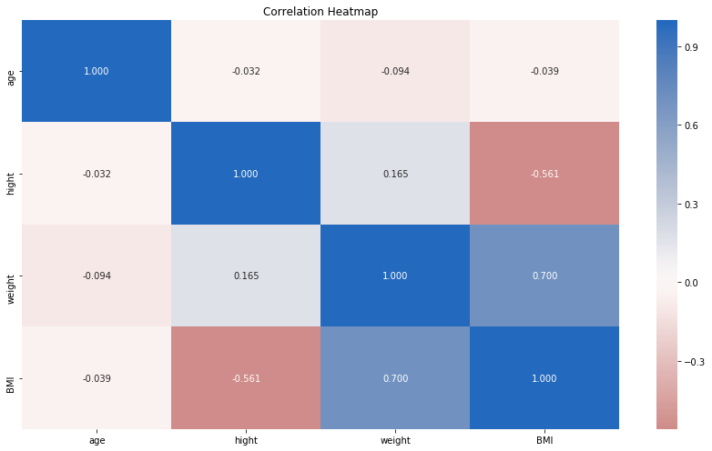

```python
# creat a heatmap that link corr to each other

plt.figure(figsize=[14.7,8.27]);
numeric_vars = ['age','hight','weight','BMI']
sb.heatmap(df[numeric_vars].corr(), annot = True, fmt = '.3f',
           cmap = 'vlag_r', center = 0);
plt.title('Correlation Heatmap');
```

> No strong linear relationship appears between independent variables.

> Create a matrix of box plots between numeric and catagorical variables

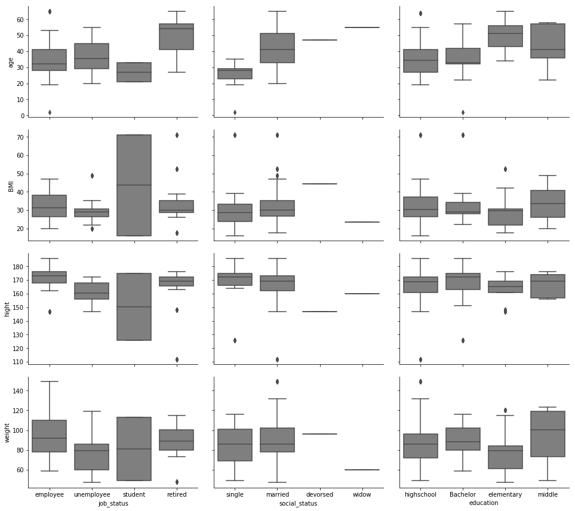

```python
# numeriv variable = age, BMI, hight, weight
#catagorical variables = job status, social status, education

def boxgrid(x, y, **kwargs):
    default_color = sb.color_palette()[7];
    sb.boxplot(x, y, color = default_color);



g = sb.PairGrid(data = df, y_vars = ['age', 'BMI','hight','weight'], x_vars = ['job_status','social_status','education'],
                size = 3, aspect = 1.5);
g.map(boxgrid);
```

> Examin a sccater plot of age & BMI

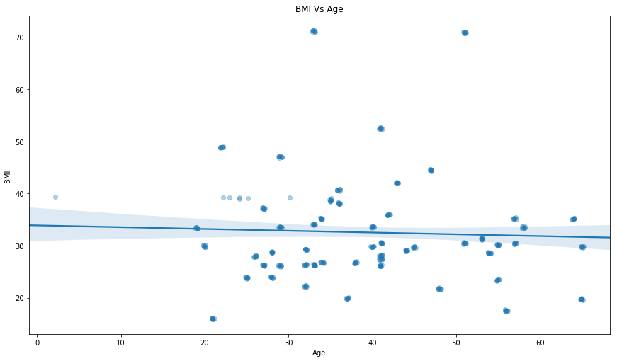

```python
# creat a sccater plot for age & BMI

plt.figure(figsize=[14.7,8.27])
sb.regplot(data = df, x = 'age', y = 'BMI', fit_reg = True,
           x_jitter = 0.2, y_jitter = 0.2, scatter_kws = {'alpha' : 1/3});
plt.xlabel('Age');
plt.ylabel('BMI ');
plt.title('BMI Vs Age');
```

> We can note that no relation exists between age and BMI variable.

# ِAnalysis Part

> At this stage we will start analyzing Q12, Q13, and Q14 along with connection variable to answer the following questions:

> 1- Are people who discussed BMI with their doctors have less BMI average?

> 2- Are people who have obese siblings have less BMI average?

> 3- What proportion of people have answered the last three questions correctly?

### Answering Question 1

> 1- Are people who discussed BMI with their doctors have less BMI average?

```python
df[df['doctor_discussion']==1]['BMI'].mean(), df[df['doctor_discussion']==0]['BMI'].mean()
```

```
(39.70888794483846, 32.08956495915826)
```

Surprisingly, people who did not discuss BMI with their doctors have a less average. Let us plot the two distributions to emphasize the results.

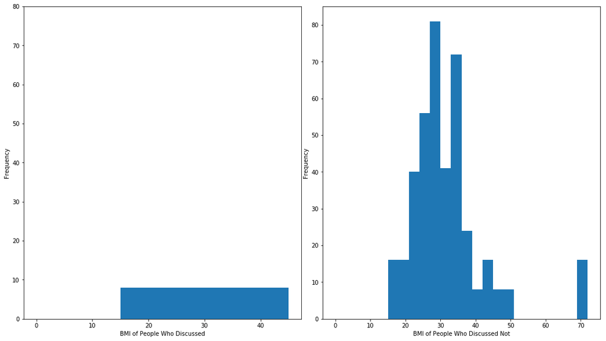

```python
# creat two histograms for the above point
temp1 = df[df['doctor_discussion']==1]
temp2 = df[df['doctor_discussion']==0]

#figure size
plt.figure(figsize=[14.7,8.27]);

#First group
plt.subplot(1,2,1);
plt.tight_layout();
bin_size = np.arange(0, temp1['BMI'].max()+2,15);
plt.hist(data=temp1, x='BMI', bins = bin_size);
plt.xlabel('BMI of People Who Discussed');
plt.ylabel('Frequency');
plt.ylim([0,80]);

#Second group
plt.subplot(1,2,2);
plt.tight_layout();
bin_size = np.arange(0, temp2['BMI'].max()+2,3);
plt.hist(data=temp2, x='BMI', bins = bin_size);
plt.xlabel('BMI of People Who Discussed Not');
plt.ylabel('Frequency');
```

It becomes clear now that who did not discuss have a lower BMI average. However, a few only had discussed.

### Answer Question 2

> 2- Are people who have obese siblings have less BMI average?

```python
df[df['siblings_obesity']==1]['BMI'].mean(), df[df['siblings_obesity']==0]['BMI'].mean()
```

```
(31.29233650543886, 33.051538771232806)
```

As shown, who has an obese sibling tend to have a lower BMI. Let us visualize the result.

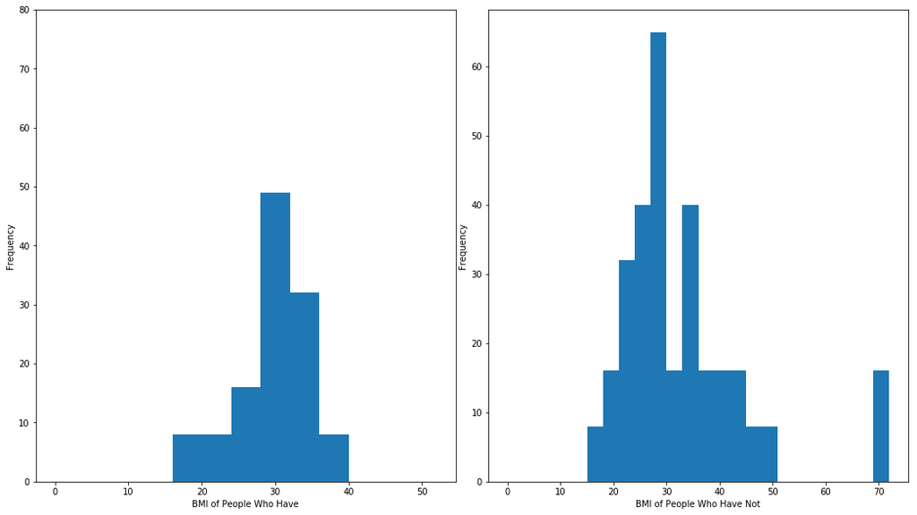

```python
# creat two histograms for the above point
temp1 = df[df['siblings_obesity']==1]
temp2 = df[df['siblings_obesity']==0]

#figure size
plt.figure(figsize=[14.7,8.27]);

#First group
plt.subplot(1,2,1);
plt.tight_layout();
bin_size = np.arange(0, temp1['BMI'].max()+2,4);
plt.hist(data=temp1, x='BMI', bins = bin_size);
plt.xlabel('BMI of People Who Have');
plt.ylabel('Frequency');
plt.ylim([0,80]);

#Second group
plt.subplot(1,2,2);
plt.tight_layout();
bin_size = np.arange(0, temp2['BMI'].max()+2,3);
plt.hist(data=temp2, x='BMI', bins = bin_size);
plt.xlabel('BMI of People Who Have Not');
plt.ylabel('Frequency');
```

It is clear now that the two distribution tend to be normal, and people who have obese siblings, have a less BMI average.

### Answering Question 3

> 3- What proportion of people have answered the last three questions correctly?

```python
correctly_answered.shape[0]/df.shape[0]
```

```
0.11267605633802817
```

We have 48 people answered correctly, let us examine the other variables for them.

> How does their BMI differ?

```python
# How does thei BMI mean differ?

( correctly_answered['BMI'].mean() - df['BMI'].mean() ) / df['BMI'].mean()
```

```
0.3196214840304756
```

Their BMI mean is higher than the overall BMI mean by 32%.

Let us plot all the other quantitative variables

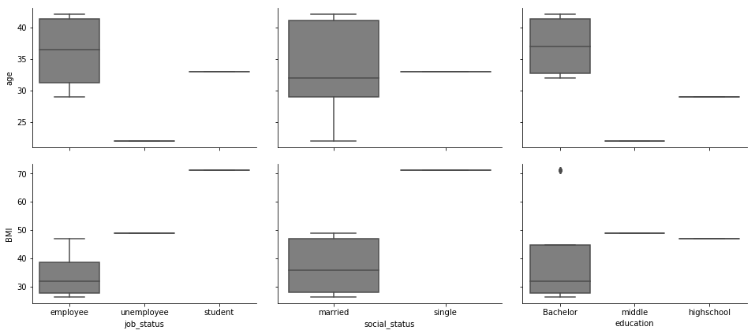

```python
# creat a box plot map for who correctly answered

# numeriv variable = age, BMI
#catagorical variables = job status, social status, education

def boxgrid(x, y, **kwargs):
    default_color = sb.color_palette()[7];
    sb.boxplot(x, y, color = default_color);

plt.figure(figsize = [14.7, 8.27]);
g = sb.PairGrid(data = correctly_answered , y_vars = ['age', 'BMI'], x_vars = ['job_status','social_status','education'],
                size = 3, aspect = 1.5);
g.map(boxgrid);
```

# Conclusion

> The distribution of the main variables of intreset, BMI, and age are random. That may be because a smal sample size was taken.

> People who discussed their Bmi with their doctors tend to have higher BMI average.